# Technologie wytwarzania elementów urządzeń mechatronicznych

dr hab. inż. Marcin Słoma, prof. PW

Zakład Mikrotechnologii i Nanotechnologii

## OBRÓBKA EROZYJNA GŁADKOŚCIOWA

### Polerowanie elektrolityczne (elektrochemiczne)

anodowe roztwarzanie metali przy przepływie prądu elektrycznego.

### Polerowanie chemiczne

w roztworach zawierającym silne związki utleniające (bez udziału prądu).

**Polerowanie chemiczne ≊ Polerowanie elektrolityczne**

Usuwanie atomów metali z powierzchni

[figure not shown]

## OBRÓBKA EROZYJNA GŁADKOŚCIOWA

### Polerowanie elektrolityczne

- zasilanie stałoprądowe o niskim napięciu
- zbiornik procesowy z tworzyw sztucznych lub ołowiu
- katoda z ołowiu, miedzi, stali nierdzewnej, …
- elektrolity
- H<sub>3</sub>PO<sub>4</sub>, HNO<sub>3</sub>, H<sub>2</sub>SO<sub>4</sub>, HCl, Na<sub>2</sub>Cr<sub>2</sub>O<sub>7</sub>, Na<sub>2</sub>SO<sub>4</sub>, NaCl, …

[figure not shown]

## OBRÓBKA EROZYJNA GŁADKOŚCIOWA

### Polerowanie elektrolityczne

[interactive chart not shown]

Able Electropolishing Co. https://www.youtube.com/watch?v=0XUS9bRSihM

## OBRÓBKA EROZYJNA GŁADKOŚCIOWA

### Polerowanie elektrolityczne (zjawiska)

- anoda: wyzwolenie atomów z sieci krystalicznej
- katoda: osadzanie metali, wydzielanie wodoru
- warstwy obróbkowe:
  - trawiąca chropowatość (gruba)
  - polerująca (cienka)
- selektywne roztwarzanie wierzchołków nierówności
- efekt ostrzowy - koncentracja ładunków na  
  wierzchołkach, lokalne zwiększenie gęstość prądu

Aby zatrzymać zjawiska chemiczne, należy wypłukać  
elementy w wodzie dejonizowanej z alkoholem i wysuszyć.

[figure not shown]

## OBRÓBKA EROZYJNA GŁADKOŚCIOWA

### Polerowanie elektrolityczne (parametry technologiczne)

[figure not shown]

- Skład elektrolitu (wodny roztwór kwasów i soli).
- Temperatura elektrolitu $T$
- Gęstość prądu $I_f$
- Czas trwania procesu $t$

Gęstość prądu - stosunek natężenia prądu $I$ do powierzchni $f$ polerowanego elementu

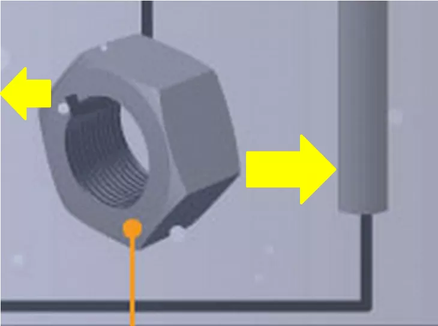

$$I_f = \frac{I}{f} \quad \left[\mathrm{A\,dm^{-2}}\right]$$

Na stabilność i wydajność procesu wpływają wszystkie powyższe parametry,  
a nawet kształt i orientacja próbki w stosunku do katody.

## OBRÓBKA EROZYJNA GŁADKOŚCIOWA

### Polerowanie elektrolityczne (parametry technologiczne)

Krzywa polaryzacji

[figure not shown]

- A: trawienie anody, gromadzenie produktów roztwarzania, wzrost rezystancji i spadek natężenia prądu.
- B: polerowanie, tworzenie błony powierzchniowej (wodorotlenki, tlenki), wzrost rezystancji w czasie.
- C: erozja, intensywne wydzielanie tlenu, odsłonięcie powierzchni metalu.

## OBRÓBKA EROZYJNA GŁADKOŚCIOWA

### Polerowanie elektrolityczne (charakterystyka)

- zmniejszenie mikrochropowatości powierzchni
- odsłonięcie struktury rdzenia (krystaliczna i fazowa)
- gratowanie, rozjaśnienie i pasywacja powierzchni

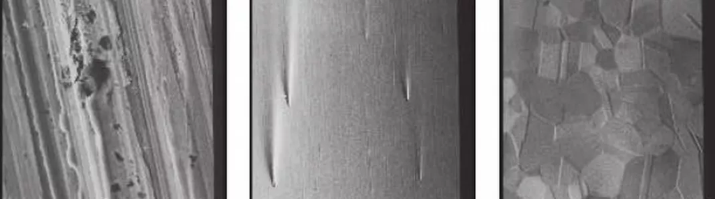

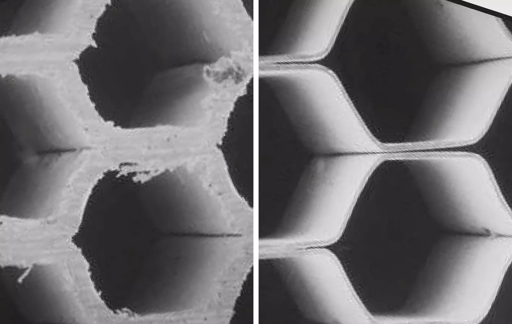

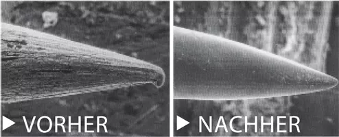

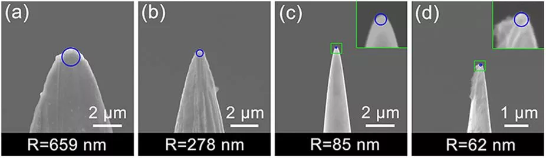

Poligrat UK Limited, R. Spitzke Oberflächen- und Galvanotechnik, Gao, Ming, et al. “Tip-induced nanoreactor for silicate.” Scientific reports 5 (2015): 14039.

## OBRÓBKA EROZYJNA GŁADKOŚCIOWA

### Polerowanie elektrolityczne (charakterystyka)

Zalety

- brak niepożądanych efektów polerowania mechanicznego
- (naprężenia mechaniczne i cieplne, cząstki wbite w powierzchnię, ślady po obróbce, …)
- w pełni zachowana odporność korozyjna (do 20 razy wyższa niż przy obróbce ściernej)
- możliwość obróbki drobnych elementów o skomplikowanych kształtach
- mechaniczna twardość powierzchni nie ma wpływu na wydajność procesu.

[figure not shown]

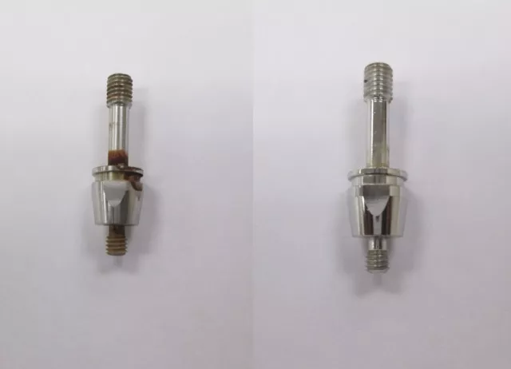

[figure not shown]

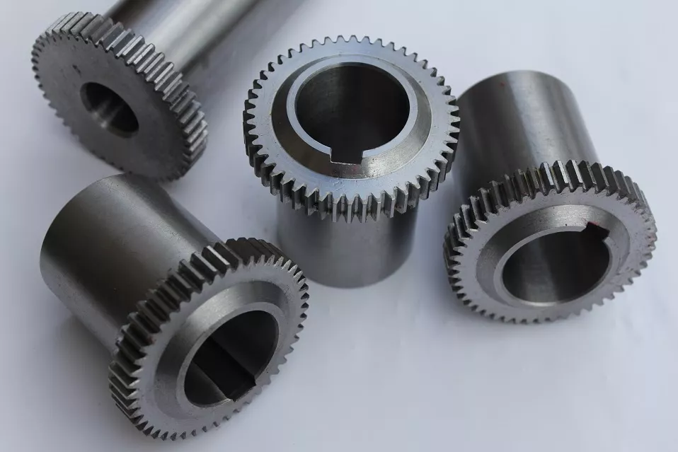

Able

## OBRÓBKA EROZYJNA GŁADKOŚCIOWA

### Polerowanie elektrolityczne (charakterystyka)

Wady

- proces chemiczny (zagrożenie dla zdrowia, zanieczyszczenia),
- ograniczona kontrola parametrów procesu, które są zmienne w czasie,
- możliwość obróbki jedynie materiałów elektroprzewodzących.

[figure not shown]

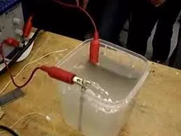

[figure not shown]

## OBRÓBKA EROZYJNA GŁADKOŚCIOWA

### Polerowanie elektrolityczne (zastosowanie)

- w końcowej fazie wytwarzania narzędzi
- przygotowanie pod nakładanie powłok
- elektrotechnika, medycyna, aparatura chemiczna, aparatura hydrauliczna, biżuteria

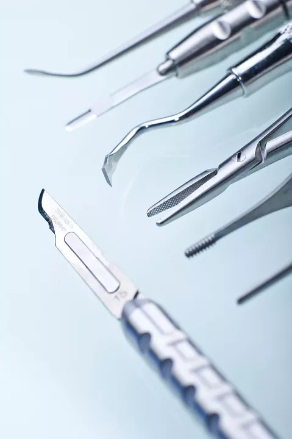

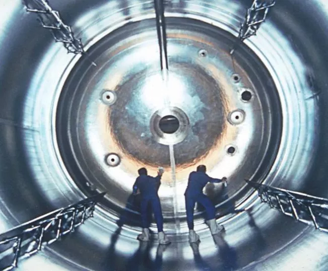

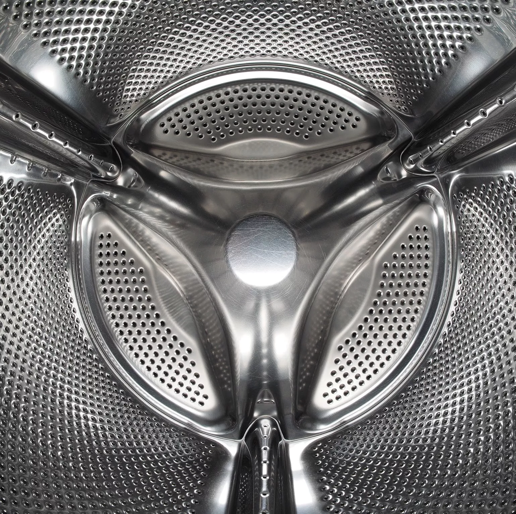

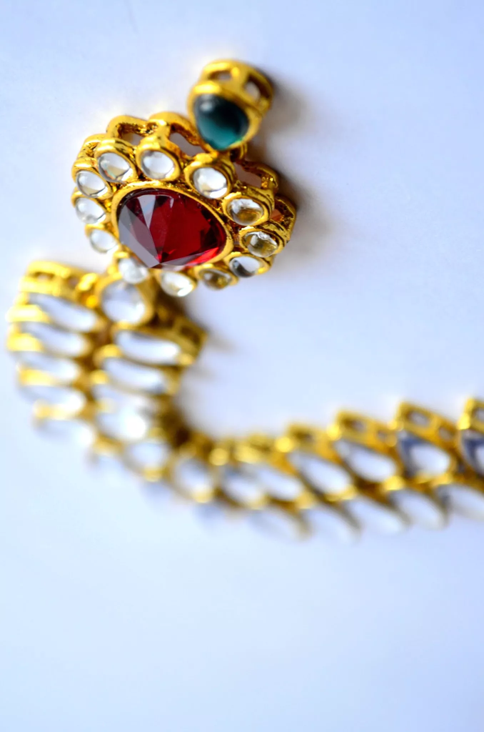

Poligrat UK Limited, Elektropol-R

## OBRÓBKA EROZYJNA GŁADKOŚCIOWA

### Polerowanie elektrolityczne

[interactive chart not shown]

Nitty-Gritty S. R. L. https://www.youtube.com/watch?v=hMV6VufvqdY

## OBRÓBKA EROZYJNA GŁADKOŚCIOWA

### Trawienie elektrolityczne

- wygładza zarysowania i ostre krawędzie,
- usuwa z wierzchniej warstwy zabrudzenia, rdzę a przede wszystkim zgorzel po spawaniu,
- usuwa przebarwienia w miejscach spawania, cięcia lub zgrzewania (powodujące korozję),
- przygotowanie powierzchni przed procesami finalnej obróbki (pasywacja, elektropolerowanie).

[figure not shown]

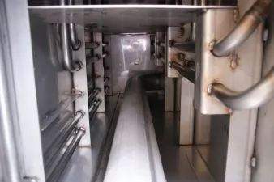

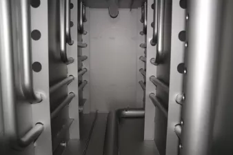

Elektropol-R, ECM

## OBRÓBKA EROZYJNA GŁADKOŚCIOWA

### Trawienie elektrolityczne

[interactive chart not shown]

xrendgen1 https://www.youtube.com/watch?v=QheQYBmEtkM

## OBRÓBKA EROZYJNA GŁADKOŚCIOWA

### Trawienie vs polerowanie elektrolityczne

element oczyszczony

trawiony

polerowany

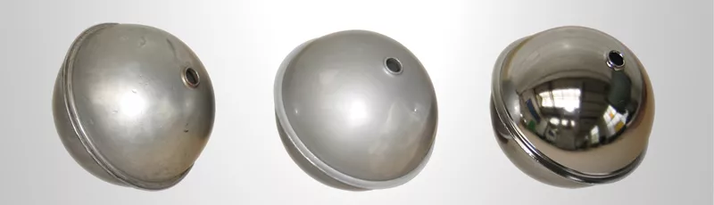

Elektropol-R

## OBRÓBKA EROZYJNA GŁADKOŚCIOWA

### Pasywacja elektrolityczna

- Samoczynna pasywacja stali nierdzewnej zachodzi spontanicznie w obecności tlenu z otoczenia.
- Proces ten może trwać kilka dni zanim warstwa pasywna osiągnie pełną grubość.
- Naturalnie wytworzona warstwa tlenków jest bardzo cienka i podatna na mechaniczne uszkodzenia.
- W niesprzyjających warunkach (wilgotność, zasolenie, czynniki agresywne) uszkodzona warstwa pasywacyjna nie odtworzy się i rozpoczyna się proces korozji.
- Proces (elektro)chemicznej pasywacji prowadzi do dziesięciokrotnego wzrostu grubości ochronnej warstwy tlenków na powierzchni wyrobu.
- Elektropolerowanie wygładza powierzchnię wyrobu, lecz obrobiona powierzchnia ulega też głębokiej anodowej pasywacji, dzięki czemu zostaje w znacznym stopniu zabezpieczona przed korozją.
- W przypadku stali chromoniklowej elektropolerowanie prowadzi do zwiększenia koncentracji atomów Cr na powierzchni (Fe i Ni trawią się szybciej) - powierzchnia ulega utwardzeniu, a dodatkowo na powierzchni wytwarza się warstwa tlenków chromu, znacznie zwiększająca odporność chemiczną.

## OBRÓBKA EROZYJNA GŁADKOŚCIOWA

### Pasywacja elektrolityczna

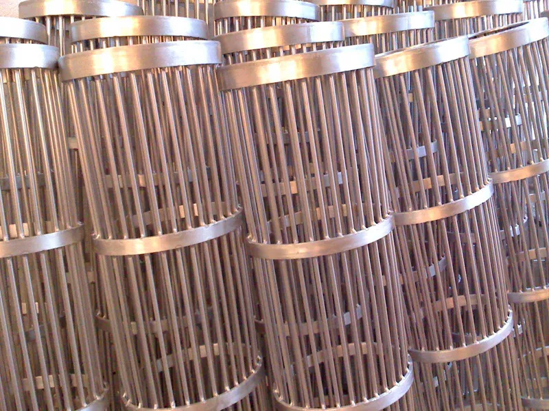

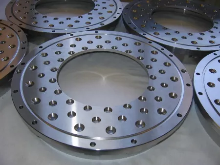

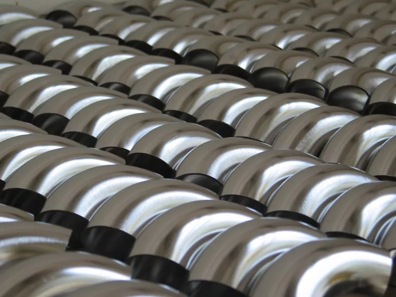

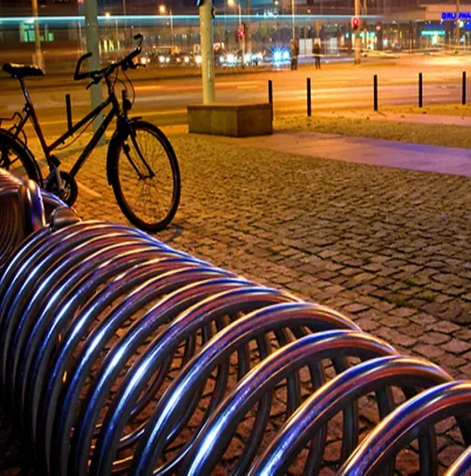

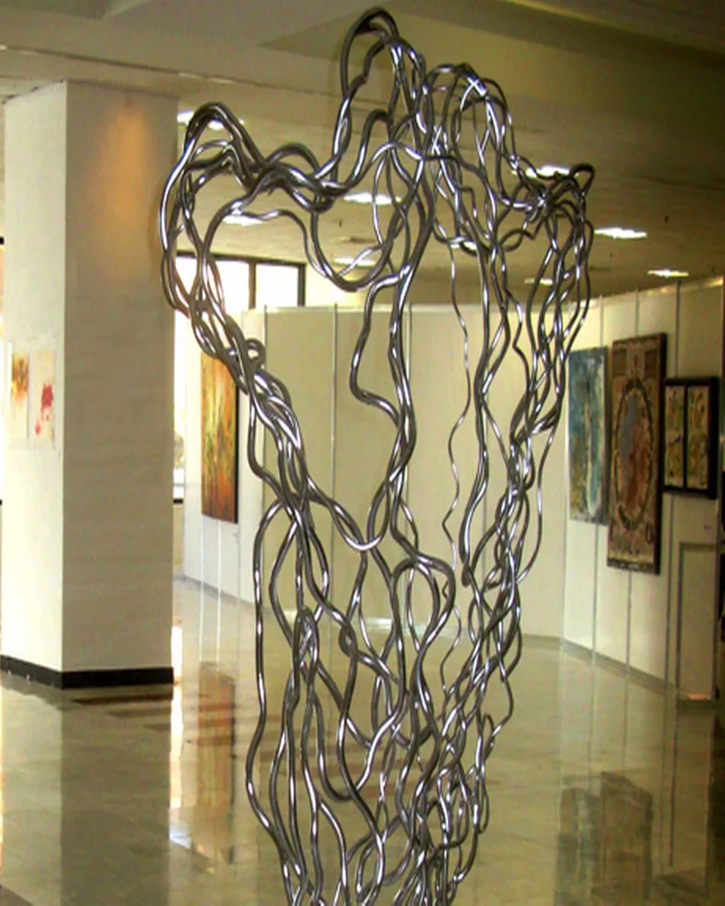

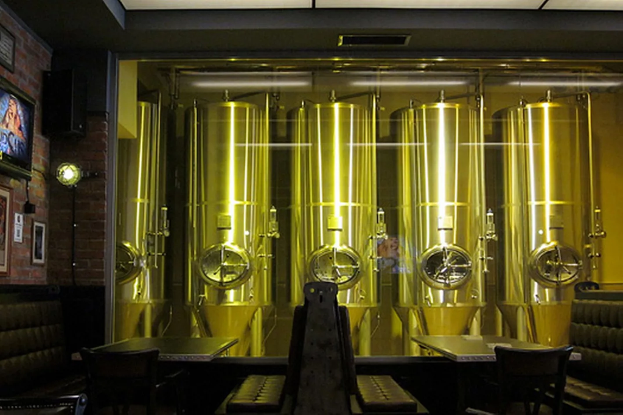

[figure not shown]

[figure not shown]

Elektropol-R, ECM, Braumax, Pinetrest, Alex Shaw

## OBRÓBKA EROZYJNA GŁADKOŚCIOWA

### Polerowanie hybrydowe

- Równoczesne zjawiska obróbki ściernej i elektrochemicznej.
- Efekt synergii: wydajność obróbki większa niż suma efektów technik składowych.
- Honowanie elektrochemiczne
- w roztworze NaCl lub NaNO<sub>3</sub>,
- osełki diamentowe o spoiwie metalowym,
- element obrabiany (anoda), osełki (katoda).

[figure not shown]

## QUIZ

- Czym różni się polerowanie ścierne od elektrolitycznego?
- Polerowanie i trawienie elektrochemiczne: proces, parametry, materiały.
- W jakim celu i jakimi metodami prowadzimy hartowanie powierzchniowe?
- Podobieństwa i różnice polerowania i powlekania elektrochemicznego.